# IE360 SPRING 2024 HOMEWORK1

Ayşe Sena Yeşilova - 2020402195

5 April 2024

#Introduction

In this analysis, I aim to provide a demonstration of my time series data manipulation and regression skills on a selection of time series data from Central Bank of the Republic of Turkey (CBRT).The research question is “To what extent do fluctuations in exchange rates and price indices influence trends in housing sales?”. Frequency of the observations is monthly and the length the period is 14 years. The relevant search volume statistics are required from google trends.

#Data processing

```r
library(ggplot2)
library(ggcorrplot)
library(directlabels)
library(tidyverse)
library(data.table)
library(readxl)
library(caret)
library(zoo)
library(xts)

setwd(getwd())

usd        <-  read_excel("usd.xlsx")
usd$Date    <-  as.Date(as.yearmon(usd$Date))
#usd        <-  xts(usd[,-1], order.by = usd$Date)

price_index <- read_excel("price_index.xlsx")
price_index$Date    <-  as.Date(as.yearmon(price_index$Date))


housing_sales <- read_excel("housing_sales.xlsx")
housing_sales$Date    <-  as.Date(as.yearmon(housing_sales$Date))



df      <-  list(usd, price_index, housing_sales) %>%
            reduce(full_join, by = "Date", copy= TRUE)
#data   <-  merge(usd, price_index, housing_sales)


satilik_ev  <-  fread("satilik_ev.csv")
colnames(satilik_ev)       <-  c("Date", "satilik_ev")
satilik_ev$Date            <-  as.Date(as.yearmon(satilik_ev$Date))

konut_kredisi  <-  fread("konut_kredisi.csv")
colnames(konut_kredisi)       <-  c("Date", "konut_kredisi")
konut_kredisi$Date            <-  as.Date(as.yearmon(konut_kredisi$Date))

df  <-  list(df, satilik_ev, konut_kredisi) %>%
        reduce(left_join, by = "Date")
```

#Data Visualizations

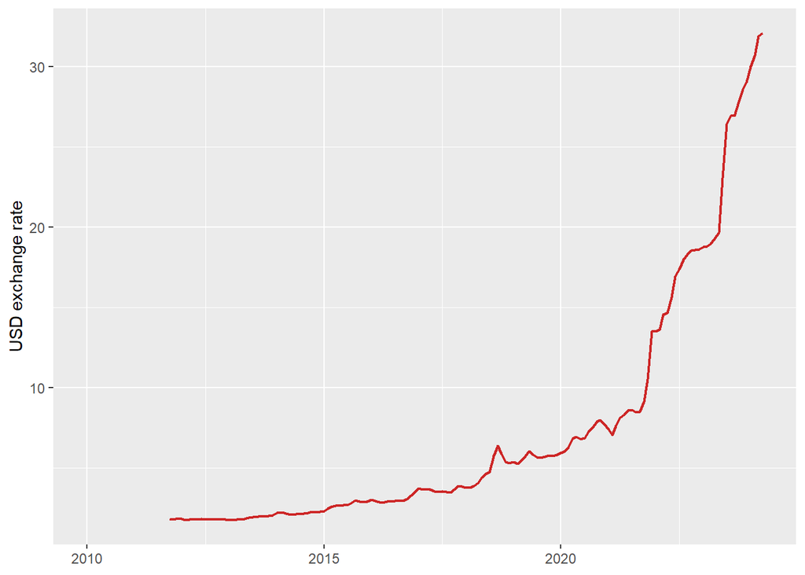

```r
ggplot(df, aes( x = Date,
                y = USD))         +

    geom_line(color = "firebrick3",
              size  = 0.75)         +

    labs(y = "USD exchange rate")      +

    theme(axis.title.x = element_blank())
```

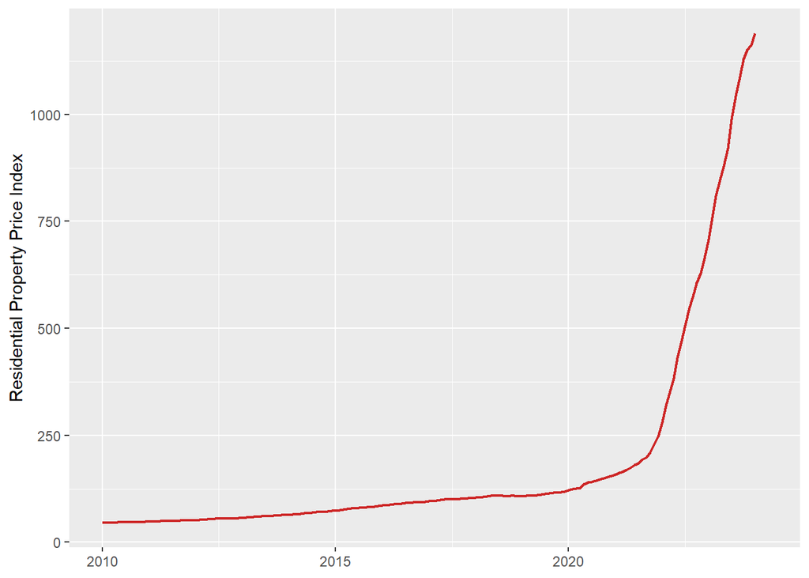

```r
ggplot(df, aes( x = Date,
                y = price_index))         +

    geom_line(color = "firebrick3",
              size  = 0.75)         +

    labs(y = "Residential Property Price Index")      +

    theme(axis.title.x = element_blank())
```

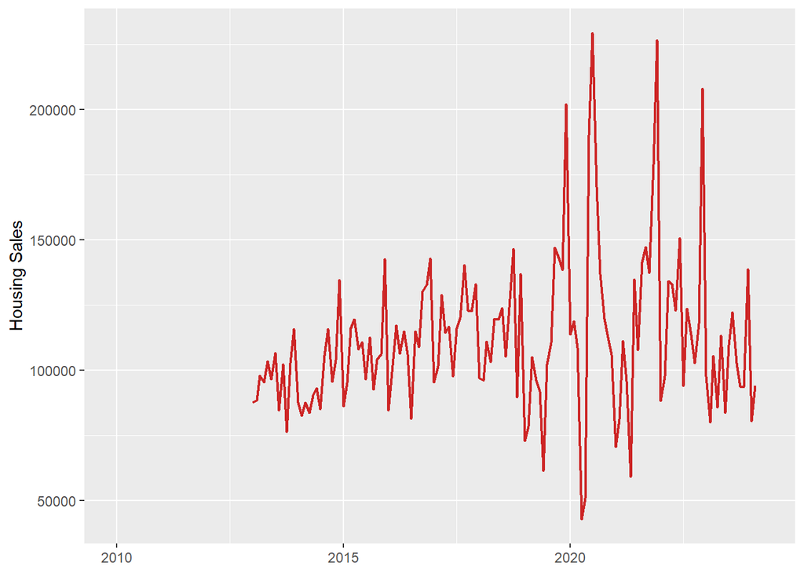

```r
ggplot(df, aes( x = Date,
                y = konut_satis))         +

    geom_line(color = "firebrick3",
              size  = 0.75)         +

    labs(y = "Housing Sales")      +

    theme(axis.title.x = element_blank())
```

Exchange rate and price index of residential properties have an exponential trend. Housing sales data is non-stationary. The aim is to understand why the housing sales data fluctuates

#Correlation Matrices

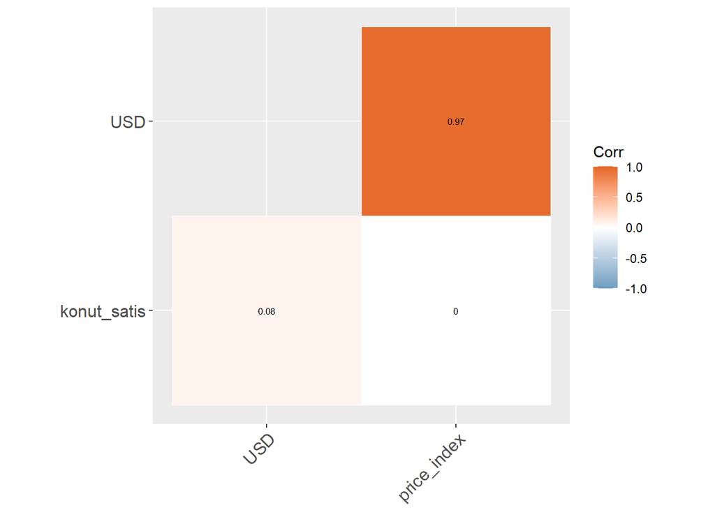

```r
df2 <- df %>% select(USD, price_index, konut_satis)
df_correl <- cor(df2[complete.cases(df2),])

ggcorrplot( df_correl,
            outline.color   = "white",
            hc.order        = TRUE,
            type            = "lower",
            lab             = TRUE,
            ggtheme         = ggplot2::theme_gray,
            lab_size        = 2.25,
            colors          = c("#6D9EC1", "white", "#E46726"))
```

#Google Trends data for search volume of “konut kredisi” and “satılık ev”

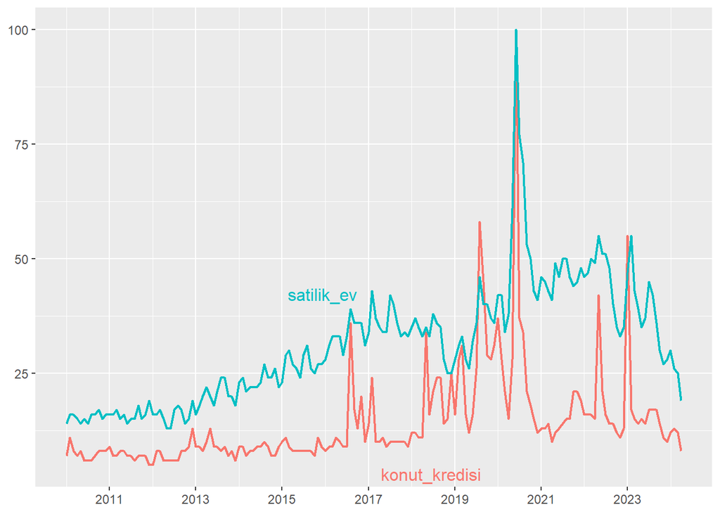

```r
df3 <- df %>%
        select(Date, satilik_ev, konut_kredisi) %>%
        gather(key = "key", value = "value", -Date)

ggplot(df3, aes(x = Date, y = value,
                group = key, color = key))              +

    geom_line(size=0.75)                                +

    scale_x_date(date_breaks = "2 years",
                 date_labels = "%Y")                    +

    theme(  legend.position = "none",
            axis.title.x    = element_blank(),
            axis.title.y    = element_blank())          +

    geom_dl(aes(label = key),
            method = list(  dl.trans(x = x + .2),
                            "smart.grid"))
```

#USD exchange rates and price indices boxplot

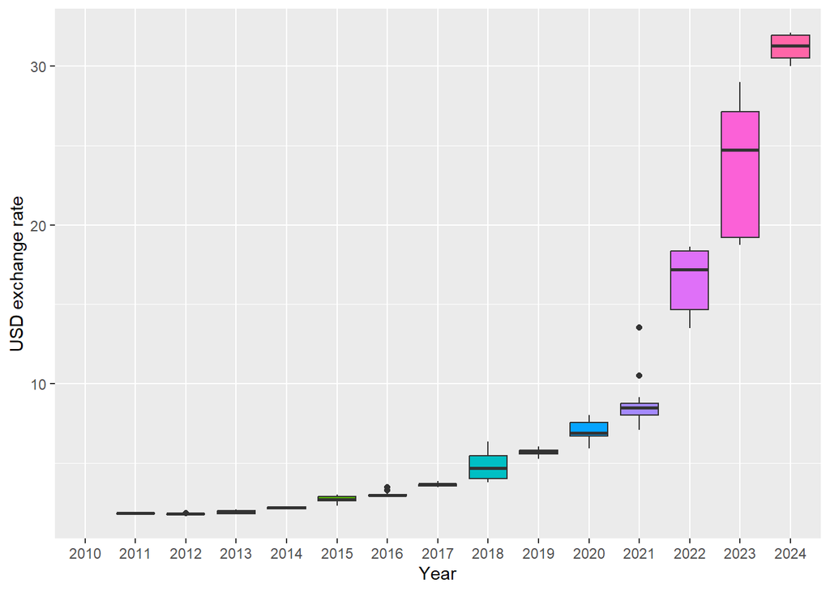

```r
ggplot(df, aes(x = factor(year(Date)), y = USD)) +
  geom_boxplot(aes(fill = factor(year(Date)))) +
  labs(y = "USD exchange rate", x = "Year") +
  theme(legend.position = "none")
```

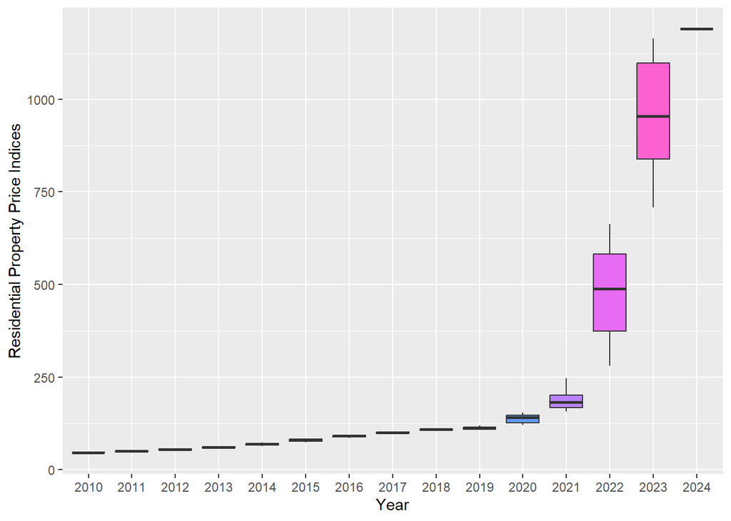

```r
ggplot(df, aes(x = factor(year(Date)), y = price_index)) +
  geom_boxplot(aes(fill = factor(year(Date)))) +
  labs(y = "Residential Property Price Indices", x = "Year") +
  theme(legend.position = "none")
```

The boxplot shows when the dollar exchange rates change the most in a year. Usd exchange rates changed most in 2023 followed by 2022 and 2018. USD exchange rates are still increasing exponentially.